# PCFL 2021: Week 3 wrap-up

### Last week’s games

| Away | Away points | Home | Home points |
| --- | --- | --- | --- |
| Jumpin’ Jaheims | 140.78 | Middle Earth Hangry Hobbits | 126.08 |
| The Sophomores TSoph | 103.24 | KC Gophers | 80.60 |
| Pigskin on the Gridiron | 125.52 | Athens Team Sasquatch | 91.59 |
| Southern Sharks | 75.74 | Georgia Peanuts | 125.84 |
| Captain Clairvoyant | 120.68 | The G.O.A.T. | 91.72 |

The marquee matchup this week was last year’s champion Sasquatch up against this year’s early leader, Pigskin on the Gridiron. The result wasn’t particularly close, with Richard leading decisively. He wasn’t the weekly points leader, though. Evan’s Jumpin’ Jaheims took that honor, winning by 14 points over the #2 team this week, Scott’s Hungry Hobbits. Tough loss, Scott.

The G.O.A.T. is continuing an early skid. Jacob had more points this week, but not enough to best Brian’s Captain Clairvoyant. The Sophomores are this season’s Cinderella team thus far, not high in the points rankings but still undefeated. Sarah’s Sharks had a rough week, as I won our inter-family matchup and broke 100 points for the first time this season.

#### Best performing players

Here’s last week’s **10 best performing players.**

| Player | Points | Team |
| --- | --- | --- |
| Josh Allen | 37.22 | Athens Team Sasquatch |
| Justin Herbert | 30.84 | Georgia Peanuts |
| Mike Williams | 29.70 | KC Gophers |
| Matthew Stafford | 29.52 | Middle Earth Hangry Hobbits |
| Tom Brady | 28.68 | Captain Clairvoyant |
| Cooper Kupp | 26.10 | Pigskin on the Gridiron |
| Davante Adams | 25.20 | Georgia Peanuts |
| Ezekiel Elliott | 25.10 | The Sophomores TSoph |
| Kareem Hunt | 24.50 | Georgia Peanuts |
| Emmanuel Sanders | 23.90 | Captain Clairvoyant |

Josh Allen and Justin Herbert were this week’s QB heroes, with Matthew Stafford and Tom Brady not far behind. Mike Williams, Cooper Kupp, and Davante Adams were the top WRs, and Ezekiel Elliot and Kareem Hunt represented the RBs.

#### Best addition and top bench

There were 9 players added last week. Which was the **best new addition**?

| Date added | Name | Points | Team |
| --- | --- | --- | --- |
| 2021-09-22 | Cordarrelle Patterson | 15.20 | Athens Team Sasquatch |
| 2021-09-22 | Panthers D/ST | 10.00 | Middle Earth Hangry Hobbits |
| 2021-09-22 | Raiders D/ST | 4.00 | Captain Clairvoyant |
| 2021-09-24 | Justin Fields | 3.92 | Georgia Peanuts |
| 2021-09-22 | Michael Carter | 3.90 | Georgia Peanuts |
| 2021-09-22 | Rondale Moore | 2.75 | Athens Team Sasquatch |
| 2021-09-22 | Sterling Shepard | 2.60 | Georgia Peanuts |
| 2021-09-23 | Quintez Cephus | 1.30 | Jumpin’ Jaheims |
| 2021-09-23 | James White | 0.60 | KC Gophers |

Who won the **best scoring bench** award last week?

| Team | Points |
| --- | --- |
| Athens Team Sasquatch | 107.32 |
| KC Gophers | 87.32 |
| The Sophomores TSoph | 87.14 |
| Captain Clairvoyant | 84.39 |
| Pigskin on the Gridiron | 78.98 |
| Middle Earth Hangry Hobbits | 74.66 |
| Southern Sharks | 69.92 |
| Jumpin’ Jaheims | 67.60 |
| The G.O.A.T. | 64.71 |
| Georgia Peanuts | 58.22 |

Robbie could have used some of the points on his bench, as he had the top scoring group this week by 20 points.

### League standings and season stats

Here’s a look at the current standings.

| Team | Division | W | L | Points scored | Points allowed | Points rank | Playoff rank |
| --- | --- | --- | --- | --- | --- | --- | --- |
| Pigskin on the Gridiron | Grits | 3 | 0 | 404.20 | 305.25 | 1 | 1 |
| The Sophomores TSoph | Hot Dish | 3 | 0 | 323.76 | 282.00 | 7 | 2 |
| Captain Clairvoyant | Grits | 2 | 1 | 367.68 | 365.60 | 2 | 3 |
| Jumpin’ Jaheims | Grits | 2 | 1 | 354.28 | 343.47 | 4 | 4 |
| Georgia Peanuts | Hot Dish | 2 | 1 | 296.74 | 291.17 | 9 | 5 |
| Middle Earth Hangry Hobbits | Hot Dish | 1 | 2 | 360.04 | 342.32 | 3 | 6 |
| Athens Team Sasquatch | Grits | 1 | 2 | 336.71 | 366.20 | 5 | 7 |
| KC Gophers | Hot Dish | 1 | 2 | 333.30 | 354.56 | 6 | 8 |
| Southern Sharks | Hot Dish | 0 | 3 | 318.30 | 383.72 | 8 | 9 |
| The G.O.A.T. | Grits | 0 | 3 | 250.82 | 311.54 | 10 | 10 |

Here’s a list of the **top five scoring performances** so far this season.

| Team | Week | Points scored | Result |
| --- | --- | --- | --- |
| KC Gophers | 1 | 149.28 | W |
| Pigskin on the Gridiron | 2 | 144.32 | W |
| Jumpin’ Jaheims | 3 | 140.78 | W |
| Middle Earth Hangry Hobbits | 2 | 139.36 | W |
| Captain Clairvoyant | 1 | 137.26 | W |

Evan’s jumped up to third on the list with his performance last week.

### Here’s a look at the **points trendline** for each team.

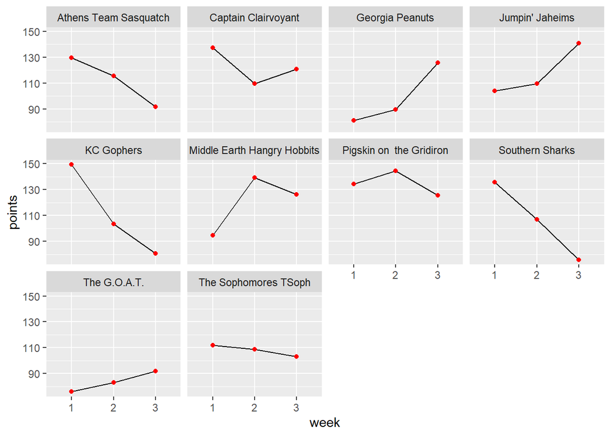

The Sasquatch, Gophers, and Sharks aren’t headed in the right direction, while Evan and I are trending up.

### If the season ended today…

Our playoff teams would be Richard, Erin/Trav, Brian, and Evan. Our last place finisher would be Jacob. But it’s still early!

### Next week’s preview

| week | game | away_team | away_points | home_team | home_points | range |
| --- | --- | --- | --- | --- | --- | --- |
| 4 | 1 | Pigskin on the Gridiron | 404.20 | The Sophomores TSoph | 323.76 | 80.44 |
| 4 | 2 | Middle Earth Hangry Hobbits | 360.04 | Southern Sharks | 318.30 | 41.74 |
| 4 | 3 | Jumpin’ Jaheims | 354.28 | Captain Clairvoyant | 367.68 | 13.40 |
| 4 | 4 | KC Gophers | 333.30 | Georgia Peanuts | 296.74 | 36.56 |
| 4 | 5 | Athens Team Sasquatch | 336.71 | The G.O.A.T. | 250.82 | 85.89 |

Good luck, y’all!